# Práctica 2.

#### XGBBoost Clasiffier

```python
from xgboost import XGBClassifier

model = XGBClassifier()
training = model.fit(X_train_smt, y_train_smt)
scores_training = cross_val_score(training, X_train_smt, y_train_smt, cv=5)
print('Mean Cross-Validation score: %.2f' % scores_training.mean())
#model saving:
joblib.dump(training, '../models/XGBBoost.pkl')
```

```
Mean Cross-Validation score: 0.99
```

```
['../models/XGBBoost.pkl']
```

```
              precision    recall  f1-score   support

           0       1.00      1.00      1.00    149150
           1       0.58      0.77      0.66       646

    accuracy                           1.00    149796
   macro avg       0.79      0.89      0.83    149796
weighted avg       1.00      1.00      1.00    149796

model score on training data: 0.9999501270424535
model score on testing data: 0.996622072685519
```

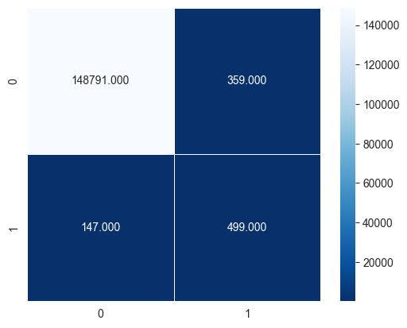

```python
model = joblib.load('../models/XGBBoost.pkl')
predictions = model.predict(X_test)
conf_matrix = confusion_matrix(y_test, predictions)

print(classification_report(y_test, predictions))
matriz_confusion(conf_matrix)
print(f'model score on training data: {model.score(X_train_smt, y_train_smt)}')
print(f'model score on testing data: {model.score(X_test, y_test)}')
```

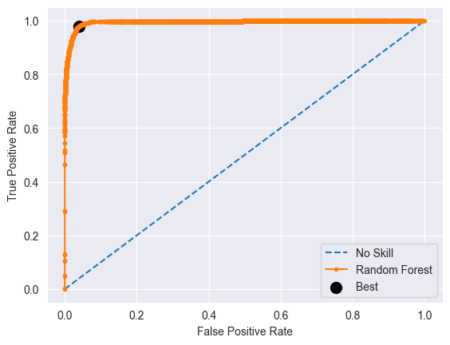

```python
y_prob = model.predict_proba(X_test)
y_hat = y_prob[:, 1]
fpr, tpr, thresholds = roc_curve(y_test, y_hat)
plt.plot([0, 1], [0, 1], linestyle='--', label='No Skill')
plt.plot(fpr, tpr, marker='.', label='Random Forest')
gmeans = np.sqrt(tpr * (1-fpr))
ix = np.argmax(gmeans)
plt.scatter(fpr[ix], tpr[ix], s=100, marker='o', color='black', label='Best')
# axis labels
plt.xlabel('False Positive Rate')
plt.ylabel('True Positive Rate')
plt.legend()
# show the plot
plt.show()
```

The XGBBoost returns similar values to Random Forest, but here the ROC curve appears be better, as the best point is closer to the upper-left corner. If we look closer at the confusion matrix, there are lower values of False Neg and False Pos values, with similar metrics that, apparently, imply a better model.

#### LightGBM

```python
import lightgbm as lgb

model = lgb.LGBMClassifier()
training = model.fit(X_train_smt, y_train_smt)
scores_training = cross_val_score(model, X_train_smt, y_train_smt, cv=5)
print('Mean Cross-Validation score: %.2f' % scores_training.mean())
#model saving:
joblib.dump(training, '../models/lightGBM.pkl')
```

```
Mean Cross-Validation score: 0.97
```

```
['../models/lightGBM.pkl']
```

```
              precision    recall  f1-score   support

           0       1.00      1.00      1.00    149150
           1       0.65      0.76      0.70       646

    accuracy                           1.00    149796
   macro avg       0.83      0.88      0.85    149796
weighted avg       1.00      1.00      1.00    149796

model score on training data: 0.9998405846535566
model score on testing data: 0.9972362412881519
```

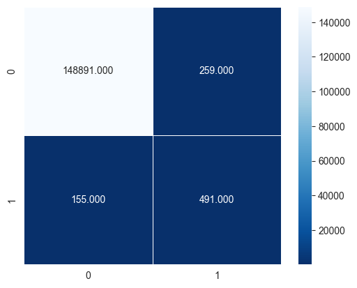

```python
model = joblib.load('../models/lightGBM.pkl')
predictions = model.predict(X_test)
conf_matrix = confusion_matrix(y_test, predictions)

print(classification_report(y_test, predictions))
matriz_confusion(conf_matrix)
print(f'model score on training data: {model.score(X_train_smt, y_train_smt)}')
print(f'model score on testing data: {model.score(X_test, y_test)}')
```

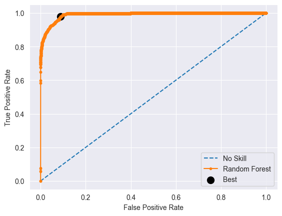

```python
y_prob = model.predict_proba(X_test)
y_hat = y_prob[:, 1]
fpr, tpr, thresholds = roc_curve(y_test, y_hat)
plt.plot([0, 1], [0, 1], linestyle='--', label='No Skill')
plt.plot(fpr, tpr, marker='.', label='Random Forest')
gmeans = np.sqrt(tpr * (1-fpr))
ix = np.argmax(gmeans)
plt.scatter(fpr[ix], tpr[ix], s=100, marker='o', color='black', label='Best')
# axis labels
plt.xlabel('False Positive Rate')
plt.ylabel('True Positive Rate')
plt.legend()
# show the plot
plt.show()
```

#### Other models

**Basic Gradient Boosting Classifier**

```python
from sklearn.ensemble import GradientBoostingClassifier

max_depth = 3 #by default, may be changed in the future.
n_estimators = 100
model = GradientBoostingClassifier(n_estimators=n_estimators, max_depth=max_depth)
training = model.fit(X_train_smt, y_train_smt)
#model saving:
joblib.dump(training, '../models/basic_gradient_boosting.pkl')
```

```
['../models/basic_gradient_boosting.pkl']
```

```
0.9943790221367727
              precision    recall  f1-score   support

           0       1.00      1.00      1.00    149150
           1       0.42      0.74      0.53       646

    accuracy                           0.99    149796
   macro avg       0.71      0.87      0.76    149796
weighted avg       1.00      0.99      1.00    149796

model score on training data: 0.9965667812260376
model score on testing data: 0.9943790221367727
```

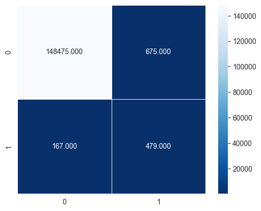

```python
model = joblib.load('../models/basic_gradient_boosting.pkl')
predictions = model.predict(X_test)
scores = model.score(X_test, y_test)

conf_matrix = confusion_matrix(y_test, pd.DataFrame(predictions))
print(scores)
print(classification_report(y_test, pd.DataFrame(predictions)))
matriz_confusion(conf_matrix)
print(f'model score on training data: {model.score(X_train_smt, y_train_smt)}')
print(f'model score on testing data: {model.score(X_test, y_test)}')
```

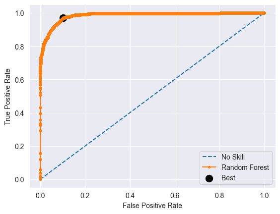

```python
y_prob = model.predict_proba(X_test)
y_hat = y_prob[:, 1]
fpr, tpr, thresholds = roc_curve(y_test, y_hat)
plt.plot([0, 1], [0, 1], linestyle='--', label='No Skill')
plt.plot(fpr, tpr, marker='.', label='Random Forest')
gmeans = np.sqrt(tpr * (1-fpr))
ix = np.argmax(gmeans)
plt.scatter(fpr[ix], tpr[ix], s=100, marker='o', color='black', label='Best')
# axis labels
plt.xlabel('False Positive Rate')
plt.ylabel('True Positive Rate')
plt.legend()
# show the plot
plt.show()
```

This model is closer to the first ones. The predictions are not good enough to be considered and the number of False Pos and False Neg are just too high, as the metrics are still poor.

**Decision Tree Classifier**

```python
from sklearn.tree import DecisionTreeClassifier

model = DecisionTreeClassifier(max_depth=5)
training = model.fit(X_train_smt, y_train_smt)
scores_training = cross_val_score(model, X_train_smt, y_train_smt, cv=5)
print('Mean Cross-Validation score: %.2f' % scores_training.mean())
#model saving:
joblib.dump(training, '../models/decision_tree_classifier.pkl')
```

```
Mean Cross-Validation score: 0.78
```

```
['../models/decision_tree_classifier.pkl']
```

```
              precision    recall  f1-score   support

           0       1.00      1.00      1.00    149150
           1       0.87      0.69      0.77       646

    accuracy                           1.00    149796
   macro avg       0.93      0.84      0.88    149796
weighted avg       1.00      1.00      1.00    149796

model score on training data: 0.929026328468642
model score on testing data: 0.9982109001575475
```

[figure not shown]

```python
model = joblib.load('../models/decision_tree_classifier.pkl')
predictions = model.predict(X_test)
print(classification_report(y_test, predictions))
matriz_confusion(conf_matrix)
print(f'model score on training data: {model.score(X_train_smt, y_train_smt)}')
print(f'model score on testing data: {model.score(X_test, y_test)}')
```

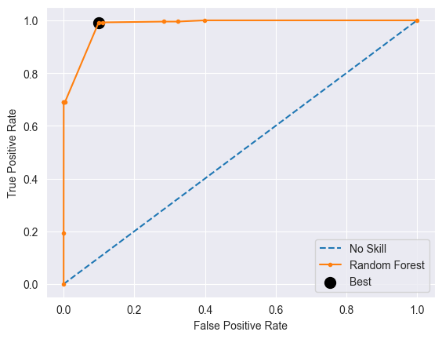

```python
y_prob = model.predict_proba(X_test)
y_hat = y_prob[:,1]
fpr, tpr, thresholds = roc_curve(y_test, y_hat)
plt.plot([0, 1], [0, 1], linestyle='--', label='No Skill')
plt.plot(fpr, tpr, marker='.', label='Random Forest')
gmeans = np.sqrt(tpr * (1-fpr))
ix = np.argmax(gmeans)
plt.scatter(fpr[ix], tpr[ix], s=100, marker='o', color='black', label='Best')
# axis labels
plt.xlabel('False Positive Rate')
plt.ylabel('True Positive Rate')
plt.legend()
# show the plot
plt.show()
```

#### 4.5 Best Model Selection

#### **XGBBoost Classifier**

Gradient boosting is a machine learning technique used in regression and classification tasks, among others. It gives a prediction model in the form of an ensemble of weak prediction models, which are typically decision trees. This the best model in Recall score, so that's the one we will develop and the one we will analyse its feature importance and interpretability.

We have chosen this model because it's the one we consider most appropriate for this particular case. We think that in a case of detection of Fraud like this one is mandatory to select a model that may be able to commit as fewer cases of False Negative as possible. After all, in a case like this, you prefer to mark a legal bank transaction as fraudulent rather than missing an actually fraudulent one.

With this premise, we have selected the model that gets good metrics but also that commits fewer relevant mistakes. Besides, we can assume a low-level of overfiting since the scores of the training and testing data are quite similar.

**ROC curve**

The ROC curve relates True Positive Rates and False Positive Rates. Classifiers that give curves closer to the top-left corner indicate a better performance. As a baseline, a random classifier is expected to give points lying along the diagonal (FPR = TPR). The closer the curve comes to the 45-degree diagonal of the ROC space, the less accurate the test.

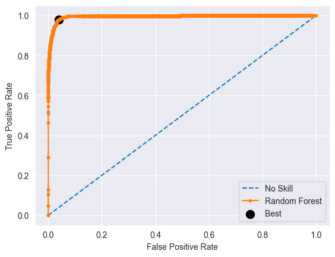

```python
# ROC CURVE

model = joblib.load('../models/XGBBoost.pkl')
y_prob = model.predict_proba(X_test)
y_hat = y_prob[:,1]
fpr, tpr, thresholds = roc_curve(y_test, y_hat)
plt.plot([0, 1], [0, 1], linestyle='--', label='No Skill')
plt.plot(fpr, tpr, marker='.', label='Random Forest')
gmeans = np.sqrt(tpr * (1 - fpr))
ix = np.argmax(gmeans)
plt.scatter(fpr[ix], tpr[ix], s=100, marker='o', color='black', label='Best')
# axis labels
plt.xlabel('False Positive Rate')
plt.ylabel('True Positive Rate')
plt.legend()
# show the plot
plt.show()
```

```python
# precision and recall of the model
precision, recall, thresholds = precision_recall_curve(y_test, y_hat)
# convert to f score
fscore = (2 * precision * recall) / (precision + recall)
# locate the index of the largest f score
ix = np.argmax(fscore)
print('Best Threshold=%f, F-Score=%.3f' % (thresholds[ix], fscore[ix]))
```

```
Best Threshold=0.490000, F-Score=0.724
```

Following the precision_recall_curve, the best threshold is set to 0.49. It indicates that the classification line that separates the target variable should be set on 0.49. The default threshold is set on 0.5, so it's not worth it to change the threshold to 0.49 instead of 0.5.

# 5. Interpretability

#### 5.1 Feature importance

```python
model = joblib.load('../models/XGBBoost.pkl')
predictions = model.predict(X_test)

importances = model.feature_importances_
indices = np.argsort(importances)
```

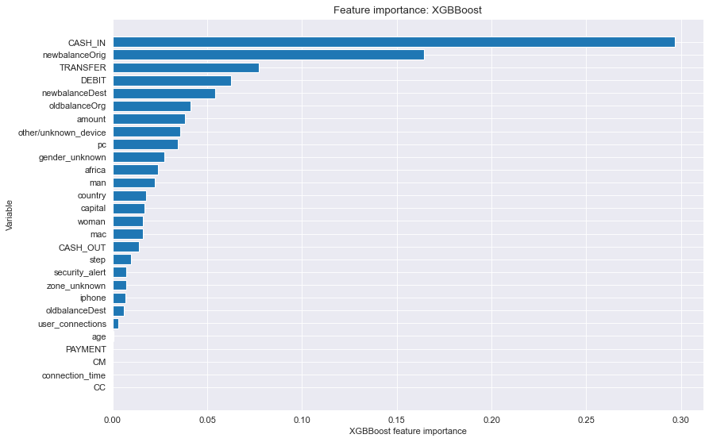

```python
sort = model.feature_importances_.argsort()
figure(figsize=(12, 8), dpi=80)
plt.barh(X_test.columns[sort], model.feature_importances_[sort])
plt.xlabel('XGBBoost feature importance')
plt.ylabel('Variable')
plt.title('Feature importance: XGBBoost')
```

**Permutation Based Feature importance**

Permutation feature importance is a model inspection technique that can be used for any fitted estimator when the data is tabular. This is especially useful for non-linear or opaque estimators. The permutation feature importance is defined to be the decrease in a model score when a single feature value is randomly shuffled. This procedure breaks the relationship between the feature and the target, thus the drop in the model score is indicative of how much the model depends on the feature. This technique benefits from being model agnostic and can be calculated many times with different permutations of the feature. [Scikit-learn]

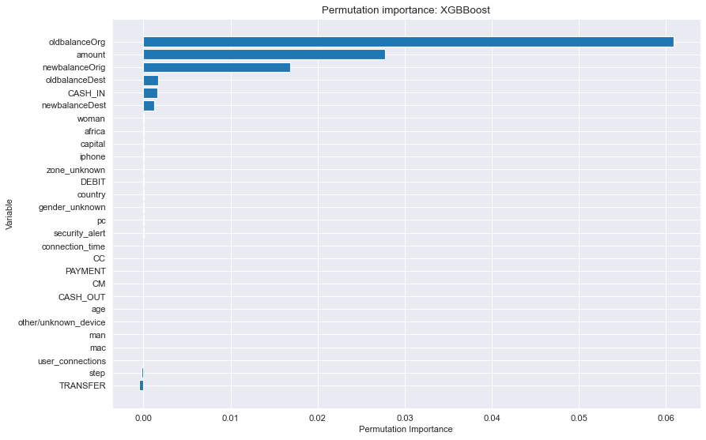

```python
perm_importance = permutation_importance(model, X_test, y_test)
sorted_idx = perm_importance.importances_mean.argsort()
figure(figsize=(12, 8), dpi=80)
plt.barh(X_test.columns[sorted_idx], perm_importance.importances_mean[sorted_idx])
plt.xlabel("Permutation Importance")
plt.ylabel('Variable')
plt.title('Permutation importance: XGBBoost')
```

```python
# Now we will use eli5 to take the importance of each variable independently for the Random Tree Classifier.
model = joblib.load('../models/XGBBoost.pkl')
explainer = PermutationImportance(model, scoring='neg_mean_absolute_error').fit(X_test, y_test)
feature_names = list(X_test.columns)
explain_weights(explainer, feature_names=feature_names)
```

[output not shown]

**Partial Dependence Plots** Partial dependence (PD) and individual conditional expectation (ICE) plots illustrate the relationships between one or more input variables and the predictions of a black-box model. They are both visual, model-agnostic techniques. For example, a PD plot can show whether estimated car price increases linearly with horsepower or whether the relationship is another type, such as a step function, curvilinear, and so on. ICE plots can explore even deeper to explore individual differences and identify subgroups and interactions between model inputs.

Now we will use the most important variables settled in feature importance to analyse its partial dependence plots:

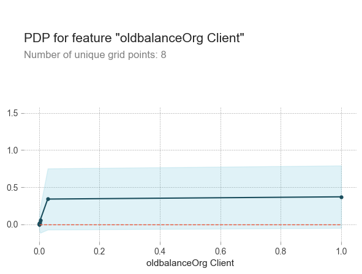

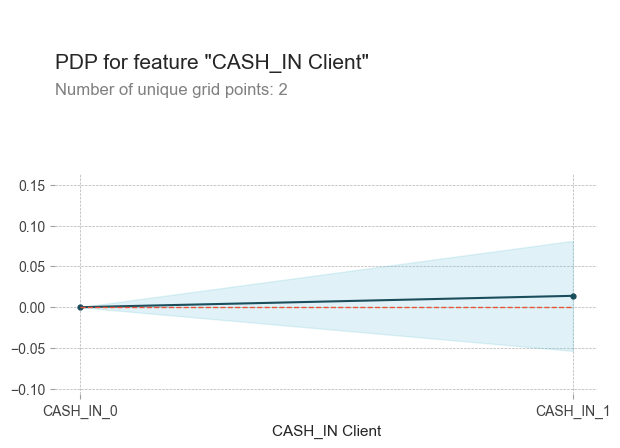

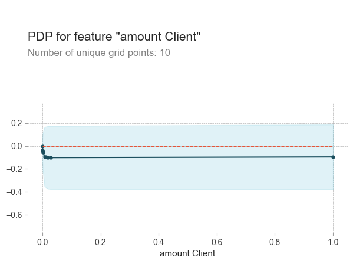

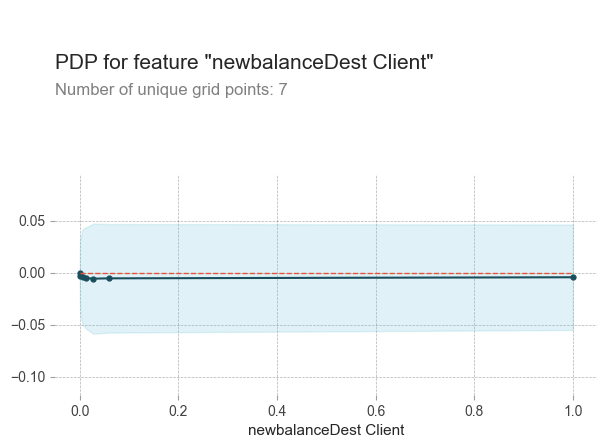

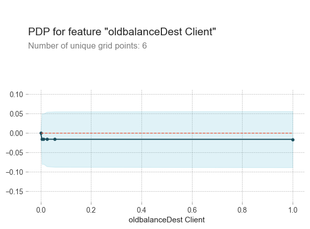

```python
important_variables = ['oldbalanceOrg', 'CASH_IN', 'amount', 'newbalanceDest', 'oldbalanceDest', 'TRANSFER']
feature_names = list(X_test.columns)
dataset = X_test
for i in important_variables:
    if i!='TRANSFER':
        pdp_age = pdp.pdp_isolate(model=model, dataset=dataset,
                                  model_features=feature_names, feature=i)
        pdp.pdp_plot(pdp_age, i + ' Client', figsize=(7,5))
    else:
        break
```

#### 5.2 Explainability

**SHAP**

SHAP (SHapley Additive exPlanations) is a game theoretic approach to explain the output of any machine learning model. It connects optimal credit allocation with local explanations using the classic Shapley values from game theory and their related extensions (see papers for details and citations).

```python
X_test_shap = X_test
```

```python
import shap
shap.initjs()
explainer = shap.TreeExplainer(model)
shap_values = explainer.shap_values(X_test_shap)
shap.force_plot(explainer.expected_value, shap_values[109,:], X_test_shap.iloc[109,:], link='logit')
```

[output not shown]

We have not been able to change the f(x) = 0 in the XGBBoost clasiffier, therefore, we will use SHAP explainability from the Random forest in order to explain the results.

**RANDOM FOREST SHAP**

```python
model = joblib.load('../models/random_forest.pkl')
```

```python
row_to_show = 394
data_for_prediction = X_test_shap.iloc[row_to_show]
data_for_prediction_array = data_for_prediction.values.reshape(1, -1)
model.predict_proba(data_for_prediction_array)
```

```
array([[0.75, 0.25]])
```

```python
import shap
explainer = shap.TreeExplainer(model)
shap_values = explainer.shap_values(data_for_prediction)

shap.force_plot(explainer.expected_value[1], shap_values[1], data_for_prediction)
```

[output not shown]

Author: David Rivero.